# Ford GoBike System Data Exploration

## (February 2019 Data)

## By: *Fady Morris Ebeid*

## Preliminary Wrangling

```python
# import all packages and set plots to be embedded inline
import numpy as np
import pandas as pd
import matplotlib.pyplot as plt
import seaborn as sns

%matplotlib inline
sns.set()
```

```python
# Make inline plots vector graphics instead of raster graphics
from IPython.display import set_matplotlib_formats
#set_matplotlib_formats('pdf', 'svg')
```

```python
# load in the dataset into a pandas dataframe
df = pd.read_csv('dataset/201902-fordgobike-tripdata.csv') #Load downloaded dataset
```

### General Properties

```python
# high-level overview of data shape and composition
print(df.shape)
```

```
(183412, 16)
```

```python
df.info()
```

```
<class 'pandas.core.frame.DataFrame'>
RangeIndex: 183412 entries, 0 to 183411
Data columns (total 16 columns):
 #   Column                   Non-Null Count   Dtype
---  ------                   --------------   -----
 0   duration_sec             183412 non-null  int64
 1   start_time               183412 non-null  object
 2   end_time                 183412 non-null  object
 3   start_station_id         183215 non-null  float64
 4   start_station_name       183215 non-null  object
 5   start_station_latitude   183412 non-null  float64
 6   start_station_longitude  183412 non-null  float64
 7   end_station_id           183215 non-null  float64
 8   end_station_name         183215 non-null  object
 9   end_station_latitude     183412 non-null  float64
 10  end_station_longitude    183412 non-null  float64
 11  bike_id                  183412 non-null  int64
 12  user_type                183412 non-null  object
 13  member_birth_year        175147 non-null  float64
 14  member_gender            175147 non-null  object
 15  bike_share_for_all_trip  183412 non-null  object
dtypes: float64(7), int64(2), object(7)
memory usage: 22.4+ MB
```

```python
display(df.head(10))
```

|  | duration_sec | start_time | end_time | start_station_id | start_station_name | start_station_latitude | start_station_longitude | end_station_id | end_station_name | end_station_latitude | end_station_longitude | bike_id | user_type | member_birth_year | member_gender | bike_share_for_all_trip |
| --- | --- | --- | --- | --- | --- | --- | --- | --- | --- | --- | --- | --- | --- | --- | --- | --- |
| 0 | 52185 | 2019-02-28 17:32:10.1450 | 2019-03-01 08:01:55.9750 | 21.0 | Montgomery St BART Station (Market St at 2nd St) | 37.789625 | -122.400811 | 13.0 | Commercial St at Montgomery St | 37.794231 | -122.402923 | 4902 | Customer | 1984.0 | Male | No |
| 1 | 42521 | 2019-02-28 18:53:21.7890 | 2019-03-01 06:42:03.0560 | 23.0 | The Embarcadero at Steuart St | 37.791464 | -122.391034 | 81.0 | Berry St at 4th St | 37.775880 | -122.393170 | 2535 | Customer | NaN | NaN | No |
| 2 | 61854 | 2019-02-28 12:13:13.2180 | 2019-03-01 05:24:08.1460 | 86.0 | Market St at Dolores St | 37.769305 | -122.426826 | 3.0 | Powell St BART Station (Market St at 4th St) | 37.786375 | -122.404904 | 5905 | Customer | 1972.0 | Male | No |
| 3 | 36490 | 2019-02-28 17:54:26.0100 | 2019-03-01 04:02:36.8420 | 375.0 | Grove St at Masonic Ave | 37.774836 | -122.446546 | 70.0 | Central Ave at Fell St | 37.773311 | -122.444293 | 6638 | Subscriber | 1989.0 | Other | No |
| 4 | 1585 | 2019-02-28 23:54:18.5490 | 2019-03-01 00:20:44.0740 | 7.0 | Frank H Ogawa Plaza | 37.804562 | -122.271738 | 222.0 | 10th Ave at E 15th St | 37.792714 | -122.248780 | 4898 | Subscriber | 1974.0 | Male | Yes |
| 5 | 1793 | 2019-02-28 23:49:58.6320 | 2019-03-01 00:19:51.7600 | 93.0 | 4th St at Mission Bay Blvd S | 37.770407 | -122.391198 | 323.0 | Broadway at Kearny | 37.798014 | -122.405950 | 5200 | Subscriber | 1959.0 | Male | No |
| 6 | 1147 | 2019-02-28 23:55:35.1040 | 2019-03-01 00:14:42.5880 | 300.0 | Palm St at Willow St | 37.317298 | -121.884995 | 312.0 | San Jose Diridon Station | 37.329732 | -121.901782 | 3803 | Subscriber | 1983.0 | Female | No |
| 7 | 1615 | 2019-02-28 23:41:06.7660 | 2019-03-01 00:08:02.7560 | 10.0 | Washington St at Kearny St | 37.795393 | -122.404770 | 127.0 | Valencia St at 21st St | 37.756708 | -122.421025 | 6329 | Subscriber | 1989.0 | Male | No |
| 8 | 1570 | 2019-02-28 23:41:48.7900 | 2019-03-01 00:07:59.7150 | 10.0 | Washington St at Kearny St | 37.795393 | -122.404770 | 127.0 | Valencia St at 21st St | 37.756708 | -122.421025 | 6548 | Subscriber | 1988.0 | Other | No |
| 9 | 1049 | 2019-02-28 23:49:47.6990 | 2019-03-01 00:07:17.0250 | 19.0 | Post St at Kearny St | 37.788975 | -122.403452 | 121.0 | Mission Playground | 37.759210 | -122.421339 | 6488 | Subscriber | 1992.0 | Male | No |

#### Correcting column data types

```python
df.dtypes
```

```
duration_sec                 int64
start_time                  object
end_time                    object
start_station_id           float64
start_station_name          object
start_station_latitude     float64
start_station_longitude    float64
end_station_id             float64
end_station_name            object
end_station_latitude       float64
end_station_longitude      float64
bike_id                      int64
user_type                   object
member_birth_year          float64
member_gender               object
bike_share_for_all_trip     object
dtype: object
```

```python
df = df.astype({'start_time': 'datetime64', 'end_time': 'datetime64'}, copy=False)
```

```python
df.dtypes
```

```
duration_sec                        int64
start_time                 datetime64[ns]
end_time                   datetime64[ns]
start_station_id                  float64
start_station_name                 object
start_station_latitude            float64
start_station_longitude           float64
end_station_id                    float64
end_station_name                   object
end_station_latitude              float64
end_station_longitude             float64
bike_id                             int64
user_type                          object
member_birth_year                 float64
member_gender                      object
bike_share_for_all_trip            object
dtype: object
```

#### Summary Statistics

```python
# descriptive statistics for numeric variables
df.describe()
```

|  | duration_sec | start_station_id | start_station_latitude | start_station_longitude | end_station_id | end_station_latitude | end_station_longitude | bike_id | member_birth_year |
| --- | --- | --- | --- | --- | --- | --- | --- | --- | --- |
| count | 183412.000000 | 183215.000000 | 183412.000000 | 183412.000000 | 183215.000000 | 183412.000000 | 183412.000000 | 183412.000000 | 175147.000000 |
| mean | 726.078435 | 138.590427 | 37.771223 | -122.352664 | 136.249123 | 37.771427 | -122.352250 | 4472.906375 | 1984.806437 |
| std | 1794.389780 | 111.778864 | 0.099581 | 0.117097 | 111.515131 | 0.099490 | 0.116673 | 1664.383394 | 10.116689 |
| min | 61.000000 | 3.000000 | 37.317298 | -122.453704 | 3.000000 | 37.317298 | -122.453704 | 11.000000 | 1878.000000 |
| 25% | 325.000000 | 47.000000 | 37.770083 | -122.412408 | 44.000000 | 37.770407 | -122.411726 | 3777.000000 | 1980.000000 |
| 50% | 514.000000 | 104.000000 | 37.780760 | -122.398285 | 100.000000 | 37.781010 | -122.398279 | 4958.000000 | 1987.000000 |
| 75% | 796.000000 | 239.000000 | 37.797280 | -122.286533 | 235.000000 | 37.797320 | -122.288045 | 5502.000000 | 1992.000000 |
| max | 85444.000000 | 398.000000 | 37.880222 | -121.874119 | 398.000000 | 37.880222 | -121.874119 | 6645.000000 | 2001.000000 |

The minimum value for `member_birth_year` is 1878, probably there are outliers in this column

#### Exploring outliers in `member_birth_year`

```python
np.sort(df.member_birth_year.unique())
```

```
array([1878., 1900., 1901., 1902., 1910., 1920., 1927., 1928., 1930.,
       1931., 1933., 1934., 1938., 1939., 1941., 1942., 1943., 1944.,
       1945., 1946., 1947., 1948., 1949., 1950., 1951., 1952., 1953.,
       1954., 1955., 1956., 1957., 1958., 1959., 1960., 1961., 1962.,
       1963., 1964., 1965., 1966., 1967., 1968., 1969., 1970., 1971.,
       1972., 1973., 1974., 1975., 1976., 1977., 1978., 1979., 1980.,
       1981., 1982., 1983., 1984., 1985., 1986., 1987., 1988., 1989.,
       1990., 1991., 1992., 1993., 1994., 1995., 1996., 1997., 1998.,
       1999., 2000., 2001.,   nan])
```

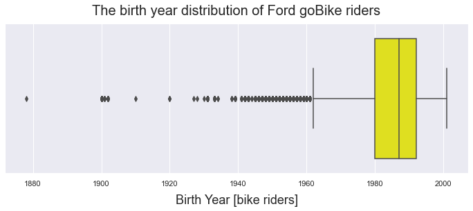

```python
plt.figure(figsize=(12,4))
sns.boxplot(x='member_birth_year', data=df, color='yellow', orient='h')
plt.title("The birth year distribution of Ford goBike riders", fontsize=20, y=1.03)
plt.xlabel("Birth Year [bike riders]", fontsize=18, labelpad=10)
#plt.savefig('image01.png');
plt.show()
```

```python
df.member_birth_year.value_counts().tail(30).sort_index()
```

```
1878.0      1
1900.0     53
1901.0      6
1902.0     11
1910.0      1
1920.0      3
1927.0      1
1928.0      1
1930.0      1
1931.0     89
1933.0     20
1934.0      2
1938.0      3
1939.0     11
1941.0      9
1942.0     21
1943.0     30
1944.0      2
1945.0    105
1946.0     19
1947.0    135
1948.0     51
1949.0     99
1950.0    178
1951.0    180
1952.0    189
1953.0    158
1954.0    301
1955.0    134
2001.0     34
Name: member_birth_year, dtype: int64
```

The large count for year 1900 suggests that it could be left as default value.

#### Duplicate rows

Checking for duplicate rows

```python
df.duplicated().sum()
```

```
0
```

#### Missing Values

```python
df.isnull().sum()
```

```
duration_sec                  0
start_time                    0
end_time                      0
start_station_id            197
start_station_name          197
start_station_latitude        0
start_station_longitude       0
end_station_id              197
end_station_name            197
end_station_latitude          0
end_station_longitude         0
bike_id                       0
user_type                     0
member_birth_year          8265
member_gender              8265
bike_share_for_all_trip       0
dtype: int64
```

#### Unique Values

```python
df.nunique()
```

```
duration_sec                 4752
start_time                 183401
end_time                   183397
start_station_id              329
start_station_name            329
start_station_latitude        334
start_station_longitude       335
end_station_id                329
end_station_name              329
end_station_latitude          335
end_station_longitude         335
bike_id                      4646
user_type                       2
member_birth_year              75
member_gender                   3
bike_share_for_all_trip         2
dtype: int64
```

## Data Cleaning

### Removing null values for gender and birth year

Drop all rows with null `member_gender` and `member_birth_year` data.

```python
df.shape
```

```
(183412, 16)
```

```python
# Get rows with null birth and gender data and print count
null_birth_gender = (df.member_birth_year.isnull() | df.member_gender.isnull())
null_birth_gender.sum()
```

```
8265
```

```python
# remove the rows from the dataframe
df = df[~ null_birth_gender]
```

```python
df.shape
```

```
(175147, 16)
```

```python
df = df.query('member_birth_year > 1931')
```

```python
df.shape
```

```
(174980, 16)
```

### Creating extra columns

#### Weekday

```python
df['weekday'] = df.start_time.dt.day_name()

weekday_order = ['Monday', 'Tuesday', 'Wednesday', 'Thursday', 'Friday', 'Saturday', 'Sunday']
wclasses = pd.api.types.CategoricalDtype(ordered = True, categories = weekday_order)

df['weekday'] = df['weekday'].astype(wclasses)
```

#### Start Hour

```python
df['start_hour'] = df.start_time.dt.hour
```

#### Age

```python
df['age'] = 2019 - df.member_birth_year
```

#### Trip Duration in minutes

```python
df['duration_minutes'] = df.duration_sec / 60
```

## Summary of Dataset

```python
df.info()
```

```
<class 'pandas.core.frame.DataFrame'>
Int64Index: 174980 entries, 0 to 183411
Data columns (total 20 columns):
 #   Column                   Non-Null Count   Dtype
---  ------                   --------------   -----
 0   duration_sec             174980 non-null  int64
 1   start_time               174980 non-null  datetime64[ns]
 2   end_time                 174980 non-null  datetime64[ns]
 3   start_station_id         174785 non-null  float64
 4   start_station_name       174785 non-null  object
 5   start_station_latitude   174980 non-null  float64
 6   start_station_longitude  174980 non-null  float64
 7   end_station_id           174785 non-null  float64
 8   end_station_name         174785 non-null  object
 9   end_station_latitude     174980 non-null  float64
 10  end_station_longitude    174980 non-null  float64
 11  bike_id                  174980 non-null  int64
 12  user_type                174980 non-null  object
 13  member_birth_year        174980 non-null  float64
 14  member_gender            174980 non-null  object
 15  bike_share_for_all_trip  174980 non-null  object
 16  weekday                  174980 non-null  category
 17  start_hour               174980 non-null  int64
 18  age                      174980 non-null  float64
 19  duration_minutes         174980 non-null  float64
dtypes: category(1), datetime64[ns](2), float64(9), int64(3), object(5)
memory usage: 26.9+ MB
```

#### What is the structure of your dataset?

This data set includes information about individual rides made in a bike-sharing system covering the greater San Francisco Bay area for February 2019.

#### What is/are the main feature(s) of interest in your dataset?

I am interested to find the relationship between days of the week, hours of the day, user type and gender to find out new insights about the bike ride system.

#### What features in the dataset do you think will help support your investigation into your feature(s) of interest?

- Trip Duration (`duration_sec`)
- `start_time` : To extract "week of the day" and "start hour"
- `user_type` : User Type
- `member_birth_year` : To calculate member age and age groups.
- `member_gender`

## Univariate Exploration

```python
base_color = sns.color_palette()[0]
```

#### Weekday usage of bikes

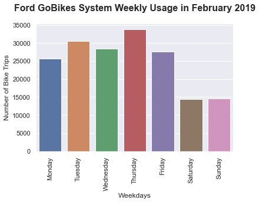

```python
sns.countplot(data = df, x='weekday');
plt.xlabel('Weekday')
plt.xticks(rotation=90);
plt.title('Ford GoBikes System Weekly Usage in February 2019',
                   y=1.07, fontsize=16, fontweight='bold');
plt.xlabel('Weekdays')
plt.ylabel('Number of Bike Trips');
```

It is apparent from the bar plot above that usage is higher on work days and lower on weekends(Saturday and Sunday)

#### Distribution of ride duration in minutes

```python
df.duration_minutes.describe()
```

```
count    174980.000000
mean         11.741417
std          27.372001
min           1.016667
25%           5.383333
50%           8.516667
75%          13.150000
max        1409.133333
Name: duration_minutes, dtype: float64
```

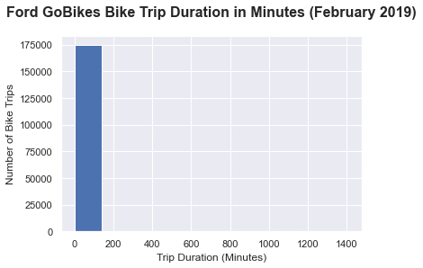

```python
df.duration_minutes.hist();

plt.title('Ford GoBikes Bike Trip Duration in Minutes (February 2019)',
                   y=1.07, fontsize=16, fontweight='bold');
plt.xlabel('Trip Duration (Minutes)')
plt.ylabel('Number of Bike Trips');
```

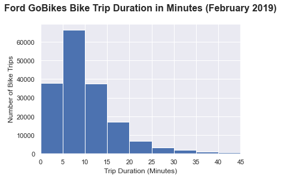

```python
duration_bins = np.arange(0,df.duration_minutes.max()+5, 5)

df.duration_minutes.hist(bins=duration_bins);
plt.xlim(0,45);

plt.title('Ford GoBikes Bike Trip Duration in Minutes (February 2019)',
                   y=1.07, fontsize=16, fontweight='bold');
plt.xlabel('Trip Duration (Minutes)')
plt.ylabel('Number of Bike Trips');
```

```python
df.duration_minutes.describe()
```

```
count    174980.000000
mean         11.741417
std          27.372001
min           1.016667
25%           5.383333
50%           8.516667
75%          13.150000
max        1409.133333
Name: duration_minutes, dtype: float64
```

```python
np.percentile(df.duration_minutes, 95)
```

```
25.55
```

```python
np.log10(df.duration_minutes.describe())
```

```
count    5.242988
mean     1.069721
std      1.437307
min      0.007179
25%      0.731051
50%      0.930270
75%      1.118926
max      3.148952
Name: duration_minutes, dtype: float64
```

```python
df.duration_minutes.mean()
```

```
11.741416828590092
```

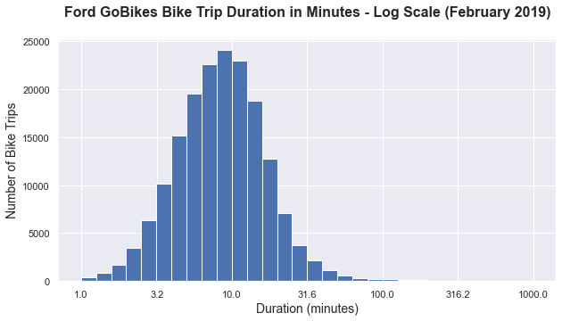

```python
# Axis transformation
# Bin size
bins = 10 ** np.arange(0, 3+0.1, 0.1)
ticks = np.round(10 ** np.arange(0,3 +0.5, 0.5),1)
labels = ['{}'.format(v) for v in ticks]


plt.figure(figsize=(10,5))
plt.hist(x=df.duration_minutes, bins=bins);

plt.xscale('log')


plt.title('Ford GoBikes Bike Trip Duration in Minutes - Log Scale (February 2019)',
                   y=1.07, fontsize=16, fontweight='bold');
plt.ylabel('Number of Bike Trips', fontsize=14);
plt.xlabel('Duration (minutes)', fontsize=14)
plt.xticks(ticks, labels)

plt.show();
```

The average duration of bike trips is almost around 11.74 minutes and median is 8.51 minutes. 95% of the data is below 25.55 minutes

#### Distirbution of hourly bike usage

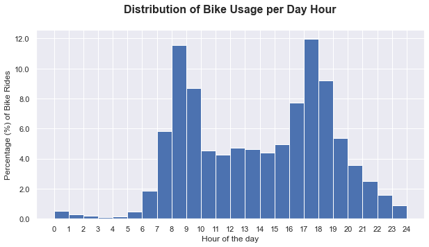

```python
bins_hour = np.arange(0,23+2,1)
max_prob = df.start_hour.value_counts().max() / df.shape[0]
tick_probs = np.arange(0,max_prob + 0.02, 0.02)

plt.figure(figsize=(10,5))
df.start_time.dt.hour.hist(bins=bins_hour);
#figure.label('Bike usage frequency for day hours')
plt.xticks(bins_hour);
plt.yticks(ticks=tick_probs * df.shape[0], labels=(tick_probs * 100).astype(str))
plt.title('Distribution of Bike Usage per Day Hour',
                   y=1.07, fontsize=16, fontweight='bold');
plt.xlabel('Hour of the day');
plt.ylabel('Percentage (%) of Bike Rides');
```

The Ford GoBike System Usage was bi-modal. It is popular between 8-9 am and 5-6 pm.

#### Age distribution (as of 2019)

```python
#age_data = 2019 - df.member_birth_year
age_bins = np.arange(10, df.age.max() + 10, 10)
```

```python
df.age.describe()
```

```
count    174980.000000
mean         34.129312
std           9.894147
min          18.000000
25%          27.000000
50%          32.000000
75%          39.000000
max          86.000000
Name: age, dtype: float64
```

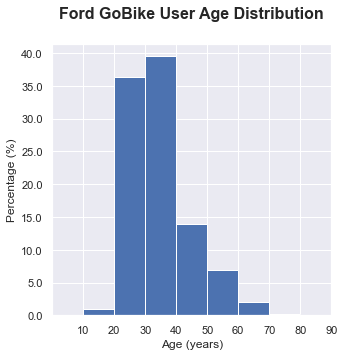

```python
plt.figure(figsize=(5,5))
freqs = plt.hist(df.age, bins=age_bins);
plt.xticks(age_bins)
plt.xlim((15,90))

max_prob = freqs[0].max() / df.shape[0]
#tick_probs = np.arange(0,max_prob + 0.01, 0.01)
tick_probs = np.arange(0,max_prob + 0.05, 0.05)
plt.yticks(ticks=tick_probs * df.shape[0], labels=(np.round(tick_probs * 100)).astype(str));

plt.xlim(0,90)
plt.title('Ford GoBike User Age Distribution',
                   y=1.07, fontsize=16, fontweight='bold');

plt.xlabel('Age (years)')
plt.ylabel('Percentage (%)');
```

```python
#frequencies
np.round(freqs[0]/freqs[0].sum()*100,1)
```

```
array([ 1. , 36.4, 39.5, 13.9,  6.9,  2. ,  0.3,  0. ])
```

The system is most popular with age group between 30-40 years old which consists of 39.5% of the users, followed by 20-30 years old group, which is 36.4% of the system users.

#### Gender distribution

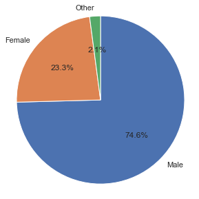

```python
gender_counts = df.member_gender.value_counts()

plt.figure(figsize=(5,5))
plt.pie(gender_counts, startangle = 90, labels = gender_counts.index, counterclock = False, autopct='%1.1f%%');

plt.axis('square');
```

The majority of system users (74%) are males, while females are 23.3% of the users.

#### Distribution of user types

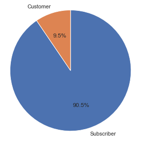

```python
user_type_counts = df.user_type.value_counts()

plt.figure(figsize=(5,5))
plt.pie(user_type_counts, startangle = 90, labels = user_type_counts.index, counterclock = False, autopct='%1.1f%%');

plt.axis('square');
```

90% of the users are subscribers, while only 9.5% of the users are customers.

### Discuss the distribution(s) of your variable(s) of interest. Were there any unusual points? Did you need to perform any transformations?

- I found that more trips were made on work days compared to weekends(Saturday and Sunday).
- Bike usage was at its peak between 8-9 am and 17-18 pm.
- Bike users were the most from the 30-40 years age group (39.5%), followed by the 20-30 age group (36.4%).
- Bike users are mostly males (74.6%), and females were only (23.3%) of total users.
- The majority of users were subscribers (90.5%) as opposed to customers (9.5%)

I had to transform the $x$-axis of the duration variable to logarithmic scale, as the data was highly right skewed and is spread over orders of magnitude.

### Of the features you investigated, were there any unusual distributions? Did you perform any operations on the data to tidy, adjust, or change the form of the data? If so, why did you do this?

The trip duration data was highly skewed and most of the data points were concenerated near the $y$-axis. I had to zoom in to see this large bulk of data. I also had to plot the $x$-axis on a logaritmic scale.

## Bivariate Exploration

#### Average Trip Duration in Minutes Per User Type

```python
user_duration_avg = df.groupby('user_type').duration_minutes.mean()
user_duration_avg = user_duration_avg.reset_index()
user_duration_avg
```

|  | user_type | duration_minutes |
| --- | --- | --- |
| 0 | Customer | 21.836809 |
| 1 | Subscriber | 10.681616 |

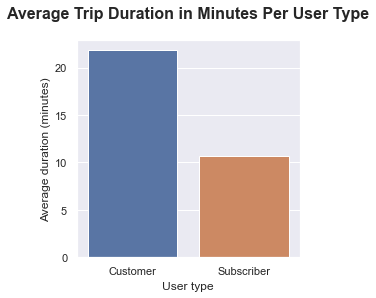

```python
base_color = sns.color_palette()[1]

plt.figure(figsize=(4,4))
ax = sns.barplot(data=user_duration_avg, x='user_type', y='duration_minutes')
#ax.set_title('Average trip duration in seconds per user type')
plt.title('Average Trip Duration in Minutes Per User Type',
                   y=1.07, fontsize=16, fontweight='bold');

plt.xlabel('User type')
plt.ylabel('Average duration (minutes)');
```

On average, customers' trip duratin is almost double that of subscribers. Customers spend on average 21.8 minutes on the trip, compared to subscribers who spend 10.6 minutes.

#### Distribution of Trip Duration in Minutes Per User Type

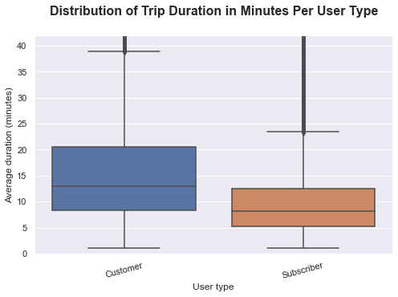

```python
plt.figure(figsize = [8, 5])
base_color = sns.color_palette()[0]

sns.boxplot(data=df, x='user_type', y='duration_minutes')
plt.xticks(rotation=15);
plt.ylim(0,42); # set y-axis limits to be same as left plot
plt.title('Distribution of Trip Duration in Minutes Per User Type',
                   y=1.07, fontsize=16, fontweight='bold');

plt.xlabel('User type')
plt.ylabel('Average duration (minutes)');
```

Distribution of customer trip time shows more variability than subscribers.

#### Bike usage of age groups per days of the week

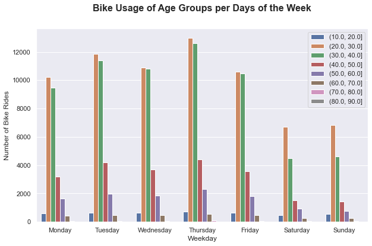

```python
plt.figure(figsize=(10,6))
ax = sns.countplot(data=df, x = 'weekday', hue = pd.cut(df.age, age_bins));
#ax.set_title('Bike usage of age groups per days of the week');
plt.title('Bike Usage of Age Groups per Days of the Week',
                   y=1.07, fontsize=16, fontweight='bold');

plt.xlabel('Weekday')
plt.ylabel('Number of Bike Rides')
plt.legend(loc='upper right');
```

Nothing special was found in the above plot

#### Distribution of Ride Duration per Days of the Week

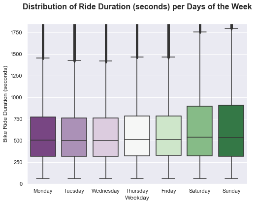

```python
fig, axes = plt.subplots(figsize=(8,6))
sns.boxplot(data=df, x="weekday", y="duration_sec", palette="PRGn")
plt.ylim(0,1850);

plt.title('Distribution of Ride Duration (seconds) per Days of the Week',
                   y=1.07, fontsize=16, fontweight='bold');

plt.xlabel('Weekday')
plt.ylabel('Bike Ride Duration (seconds)');
```

#### Customer vs. subscriber frequency along hours of the day

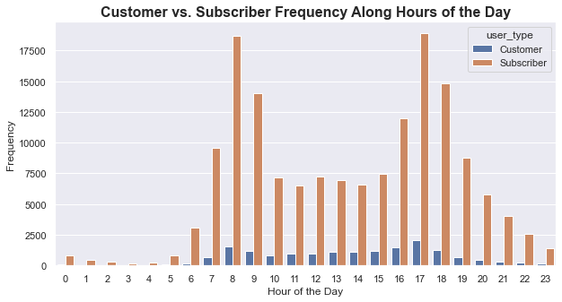

```python
plt.figure(figsize=(10,5))
ax = sns.countplot(x = df.start_time.dt.hour, hue = df.user_type);
#ax.set_title('Customer vs. subscriber frequency along hours of the day');
plt.title('Customer vs. Subscriber Frequency Along Hours of the Day',
                   y=1, fontsize=16, fontweight='bold');

plt.xlabel('Hour of the Day')
plt.ylabel('Frequency');
```

#### Customer vs. Subscriber Trends in February 2019

```python
df_sub = df.groupby(['weekday', 'user_type']).size().reset_index()
df_sub.columns = df_sub.columns[:2].append(pd.Index(['frequency']))
df_sub
```

|  | weekday | user_type | frequency |
| --- | --- | --- | --- |
| 0 | Monday | Customer | 2323 |
| 1 | Monday | Subscriber | 23315 |
| 2 | Tuesday | Customer | 2281 |
| 3 | Tuesday | Subscriber | 28317 |
| 4 | Wednesday | Customer | 2117 |
| 5 | Wednesday | Subscriber | 26312 |
| 6 | Thursday | Customer | 2875 |
| 7 | Thursday | Subscriber | 30845 |
| 8 | Friday | Customer | 2542 |
| 9 | Friday | Subscriber | 25103 |
| 10 | Saturday | Customer | 2182 |
| 11 | Saturday | Subscriber | 12256 |
| 12 | Sunday | Customer | 2304 |
| 13 | Sunday | Subscriber | 12208 |

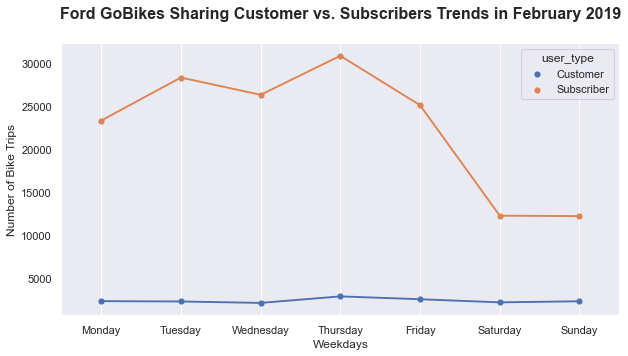

```python
plt.figure(figsize=(10, 5))
ax = sns.pointplot(data=df_sub, x='weekday', y='frequency', hue = 'user_type', scale=.7);
plt.title('Ford GoBikes Sharing Customer vs. Subscribers Trends in February 2019', y=1.07,
          fontsize=16, fontweight='bold')
plt.xlabel('Weekdays')
plt.ylabel('Number of Bike Trips');
plt.grid()
```

It is apparent that bike trips are popular with subscribers on work weekdays (Monday to Friday) and shows a decline on weekends(Saturdays and Sundays).

Customers' usage of bikes is consistent on all week days.

#### Male vs. Female Trends in February 2019

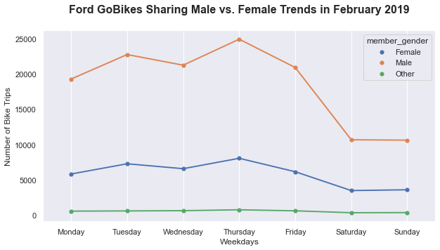

```python
df_sub = df.groupby(['weekday', 'member_gender']).size().reset_index()
df_sub.columns = df_sub.columns[:2].append(pd.Index(['frequency']))

plt.figure(figsize=(10, 5))
ax = sns.pointplot(data=df_sub, x='weekday', y='frequency', hue = 'member_gender', scale=.7);
plt.title('Ford GoBikes Sharing Male vs. Female Trends in February 2019', y=1.07,
          fontsize=16, fontweight='bold')
plt.xlabel('Weekdays')
plt.ylabel('Number of Bike Trips');
plt.grid()
```

### Talk about some of the relationships you observed in this part of the investigation. How did the feature(s) of interest vary with other features in the dataset?

- On average, customers make significantly longer trips in duration as opposed to subscribers, with higher variability.
- The distribution of age groups per days of the week is almost the same.
- Ride duration shows higher variability on weekends(Saturday and Sunday).
- Customer and subscriber frequencies along hours of the day show similar distributions.

### Did you observe any interesting relationships between the other features (not the main feature(s) of interest)?

An interesting observation was observed, Number of bike trips for subscribers fall sharply on weekends, as opposed to customers which stays almost the same for all days.

## Multivariate Exploration

```python
#set_matplotlib_formats('png')
```

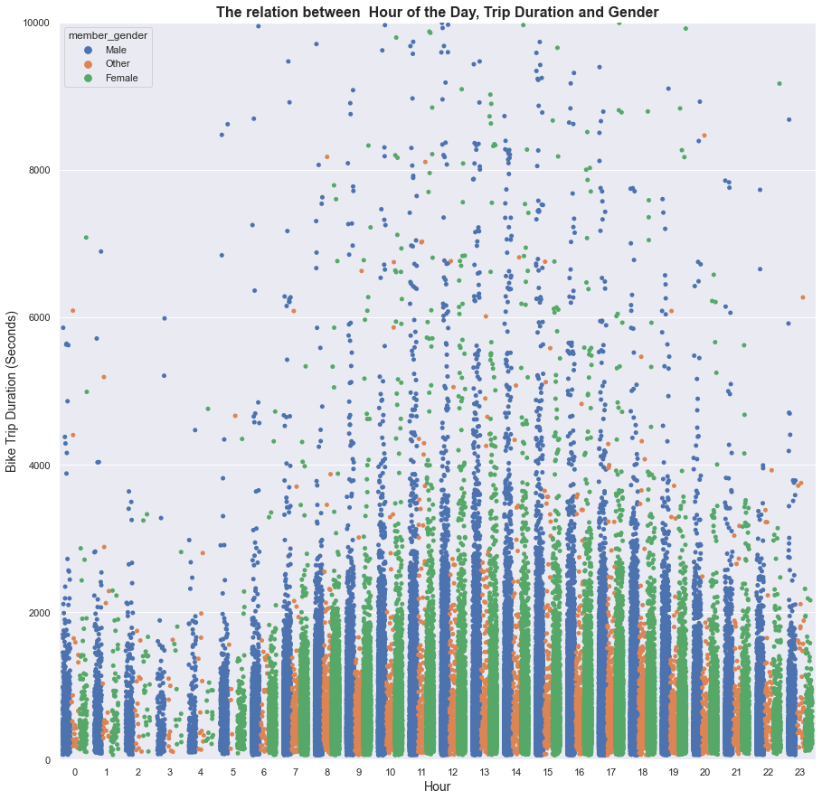

```python
plt.figure(figsize =[15, 15])

sns.stripplot(data =df, x=df.start_time.dt.hour , y="duration_sec", hue = 'member_gender', jitter= 0.35, dodge =True)


plt.ylim(0,10000)
plt.title('The relation between  Hour of the Day, Trip Duration and Gender', y=1,
          fontsize=16, fontweight='bold')

plt.xlabel("Hour", fontsize=14)
plt.ylabel("Bike Trip Duration (Seconds)", fontsize=14);
```

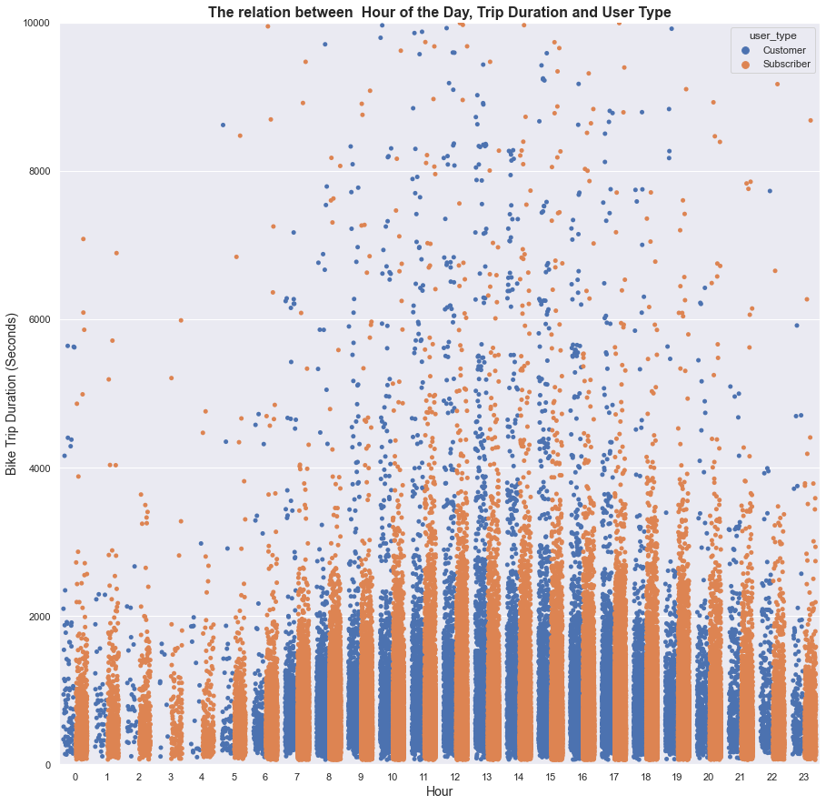

```python
plt.figure(figsize =[15, 15])

sns.stripplot(data =df, x=df.start_time.dt.hour , y="duration_sec", hue = 'user_type', jitter= 0.35, dodge =True)


plt.ylim(0,10000)
plt.title('The relation between  Hour of the Day, Trip Duration and User Type', y=1,
          fontsize=16, fontweight='bold')

plt.xlabel("Hour", fontsize=14)
plt.ylabel("Bike Trip Duration (Seconds)", fontsize=14);
```

### Were there any interesting or surprising interactions between features?

The interaction between hour, trip duration, gender and user type were surprising. It showed that the time between 12 am to 5 am is significantly different.